# GLM para dados discretos

Maria Carolina Pacheco

## 1 Introdução

Vou utilizar o banco de dados de Bentos.

```r
# Abrindo o banco de dados
benthos <- readRDS("../Dados/benthos_exposure.rds")

# Familiarizando com a estrutura do banco de dados
str(benthos)
```

```
## 'data.frame':    45 obs. of  5 variables:
##  $ Sample  : int  1 2 3 4 5 6 7 8 9 10 ...
##  $ Richness: int  11 10 13 11 10 8 9 8 19 17 ...
##  $ Exposure: int  10 10 10 10 10 8 8 8 8 8 ...
##  $ NAP     : num  0.045 -1.036 -1.336 0.616 -0.684 ...
##  $ Beach   : int  1 1 1 1 1 2 2 2 2 2 ...
```

```r
View(benthos)

# Transformando logo em fator o que vamos usar
benthos[, c("Exposure", "Beach", "Sample")] <- lapply(benthos[, c("Exposure", "Beach", "Sample")], factor)
```

## 2 Análise exploratória

Vamos começar a explorar os dados para entender sua distribuição, pensar em padrões e no que vamos testar

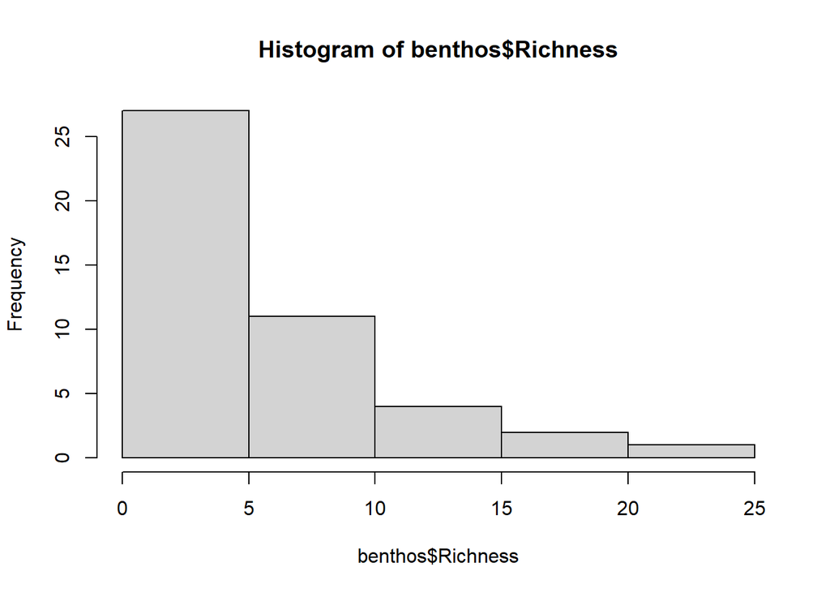

```r
# Distribuição dos dados (variável y)
hist(benthos$Richness)
```

```r
summary(benthos$Richness)
```

```
##    Min. 1st Qu.  Median    Mean 3rd Qu.    Max.
##   0.000   3.000   4.000   5.689   8.000  22.000
```

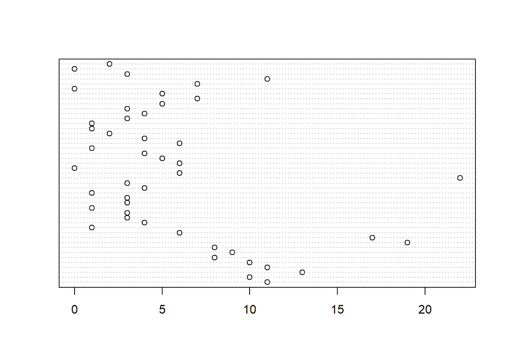

```r
dotchart(benthos$Richness)
```

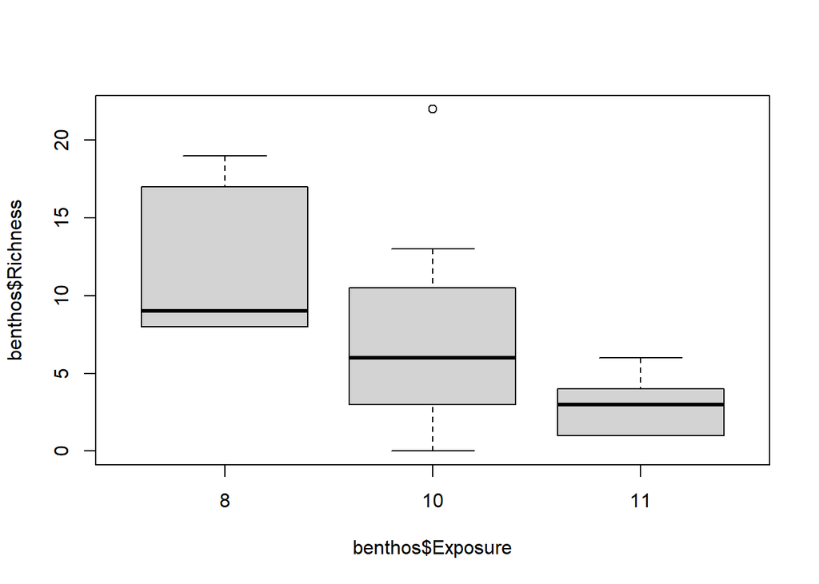

```r
plot(benthos$Richness ~ benthos$Exposure)
```

Vemos uma tendência de menor riqueza quanto maior o nível de exposição. Agora vamos relacionar com a altura da maré.

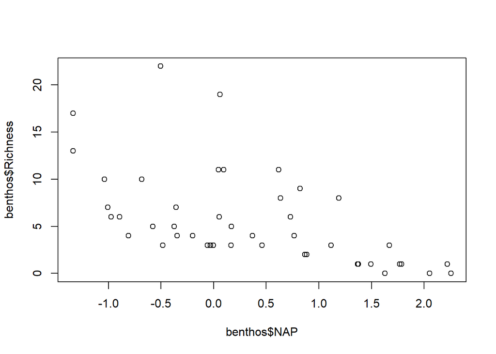

```r
plot(benthos$Richness ~benthos$NAP)
```

Tendência de diminuição da riqueza de espécies nas maiores alturas de maré. Vamos ver se a riqueza muda entre praias.

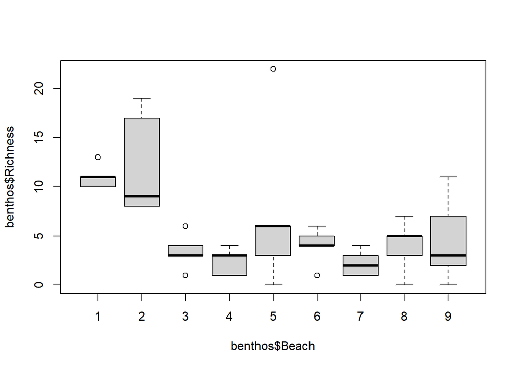

```r
plot(benthos$Richness ~ benthos$Beach)
```

Somente as praias 1 e 2 parecem diferentes das outras.

## 3 Hipóteses e predições

A partir dessa breve análise exploratória, conseguimos pensar em algumas hipóteses e predições:

- O nível de exposição do bentos é um fator determinante na riqueza de espécies, de modo que, quanto maior a exposição, menor é a riqueza.
- A altura da maré influencia negativamente a riqueza de espécies.
- A riqueza de espécies varia entre praias.

## 4 Análises e Resultados

Vou testar diferentes formas de fazer os modelos para depois comparar usando AIC

```r
# Modelo 1: Vendo o efeito aditivo da exposição com a altura da maré sobre a riqueza de espécies
mod_benthos1 <- glm(Richness ~ Exposure + NAP,
             data = benthos,
             family = "poisson")

# Modelo 2: Adicionando o efeito da praia no modelo anterior
mod_benthos2 <- glm(Richness ~ Exposure + NAP + Beach,
                    data = benthos,
                    family = "poisson")


# Comparando os três modelos com AIC
AIC(mod_benthos1, mod_benthos2)
```

```
##              df      AIC
## mod_benthos1  4 208.3707
## mod_benthos2 10 209.0714
```

O AIC dos modelos não mudou muito, mas aparentemente o modelo 1, sem o efeito da praia, consegue explicar melhor a variação dos dados. Vamos ver o ajuste do modelo 1.

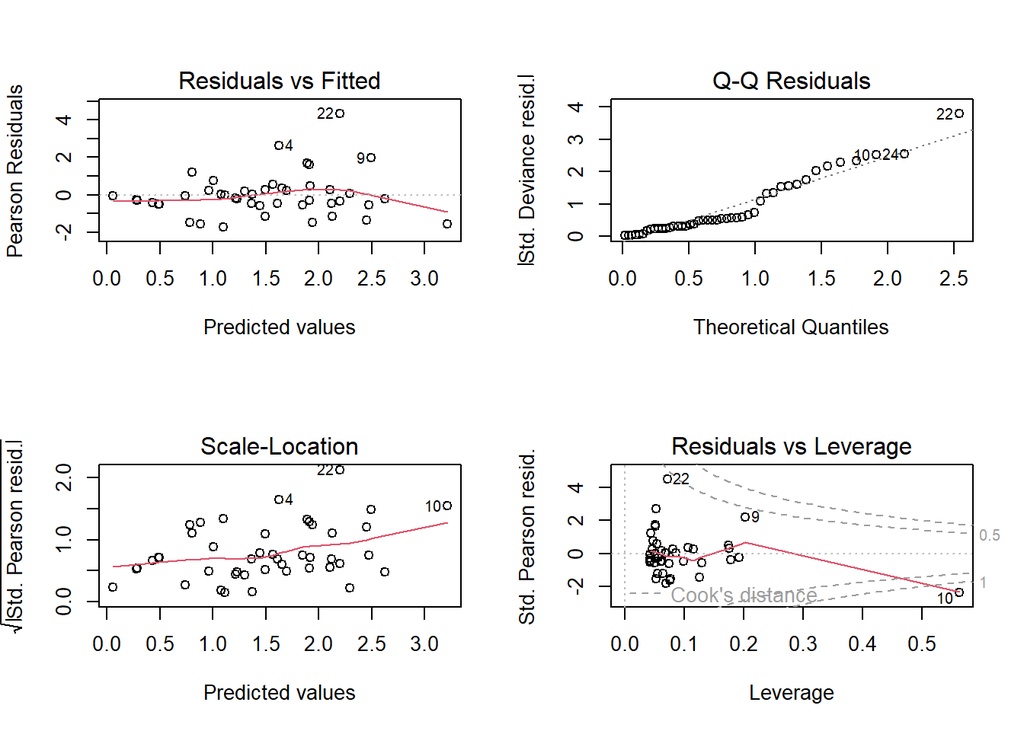

```r
# Analisar o ajuste do modelo 1, que foi o melhor
par(mfrow=c(2,2))
plot(mod_benthos1) # Olhando por esses gráficos não parece muito bom.
```

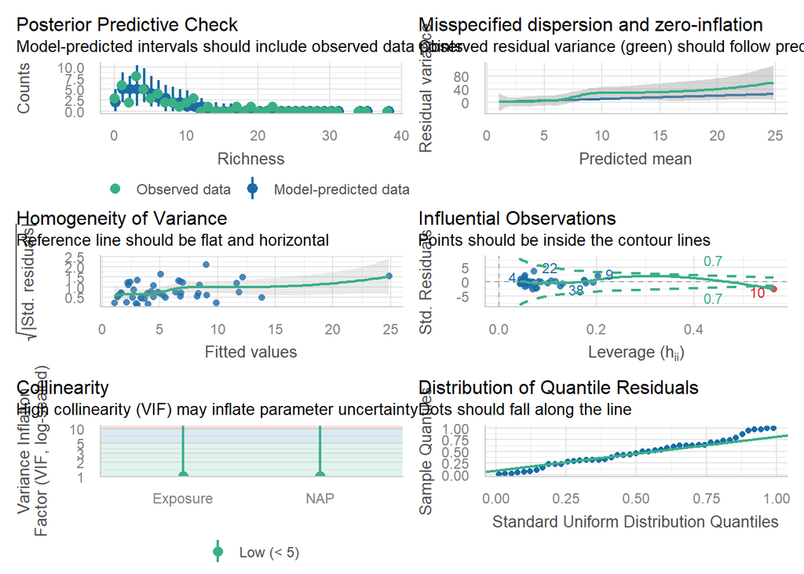

```r
check_model(mod_benthos1) #Por aqui parece um pouquinho melhor, não tem nada muito alarmante
```

```r
# Checar se tem sobredispersão
check_overdispersion(mod_benthos1)
```

```
## # Overdispersion test
##
##        dispersion ratio =  1.410
##   Pearson's Chi-Squared = 57.821
##                 p-value =  0.042
```

```
## Overdispersion detected.
```

O teste de sobre dispersão detectou sobredispersão. Pode ser que esse problema seja resolvido se usarmos distribuição Binomial Negativa em vez de Poisson.

```r
mod_benthos3 <- glm.nb(Richness ~ Exposure + NAP,
                data = benthos)

# Comparando com o modelo anterior

AIC(mod_benthos1, mod_benthos3)
```

```
##              df      AIC
## mod_benthos1  4 208.3707
## mod_benthos3  5 206.0406
```

Vemos agora que o AIC reduziu no modelo usando dsitribuição binomial negativa. Vamos checar os residuos pra validar o ajuste do modelo

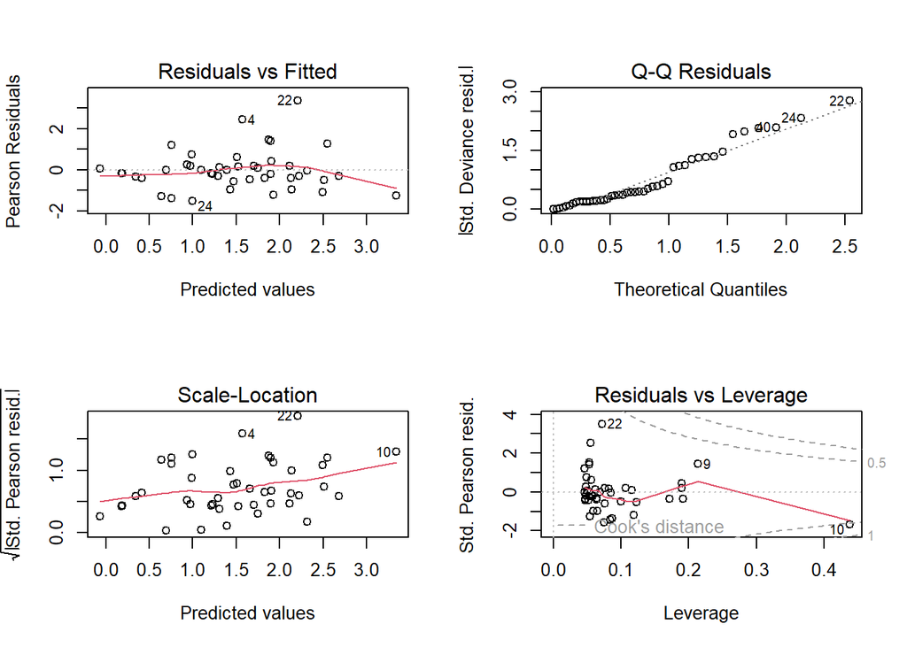

```r
par(mfrow=c(2,2))
plot(mod_benthos3) #Ainda não achei tão bom
```

```r
check_overdispersion(mod_benthos3) #Mas pelo menos não tem sobredispersão
```

```
## # Overdispersion test
##
##  dispersion ratio = 1.203
##           p-value = 0.416
```

```
## No overdispersion detected.
```

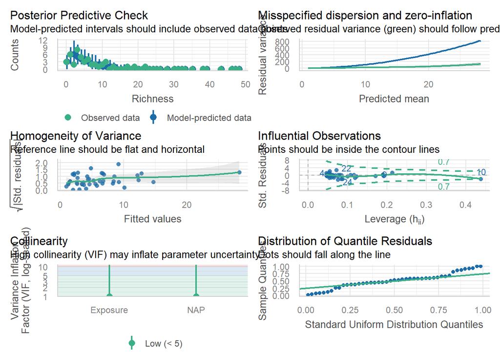

```r
check_model(mod_benthos3) # Aqui achei que piorou o gráfico da variância residual. A linha dos dados observados está mais longe da predita do que no modelo 1
```

Vou testar se os dados estão zero-inflacionados e se é isso que está causando o desvio na variância residual.

```r
check_zeroinflation(mod_benthos3)
```

```
## # Check for zero-inflation
##
##    Observed zeros: 3
##   Predicted zeros: 3
##             Ratio: 1.05
```

```
## Model seems ok, ratio of observed and predicted zeros is within the
##   tolerance range (p > .999).
```

Aparentemente os dados não são zero-inflacionados. vamos interpretar os resultados do modelo

```r
summary(mod_benthos3)
```

```
##
## Call:
## glm.nb(formula = Richness ~ Exposure + NAP, data = benthos, init.theta = 15.25376444,
##     link = log)
##
## Coefficients:
##             Estimate Std. Error z value Pr(>|z|)
## (Intercept)  2.58315    0.17500  14.761  < 2e-16 ***
## Exposure10  -0.65777    0.20503  -3.208  0.00134 **
## Exposure11  -1.38820    0.22636  -6.133 8.64e-10 ***
## NAP         -0.56909    0.08566  -6.644 3.05e-11 ***
## ---
## Signif. codes:  0 '***' 0.001 '**' 0.01 '*' 0.05 '.' 0.1 ' ' 1
##
## (Dispersion parameter for Negative Binomial(15.2538) family taken to be 1)
##
##     Null deviance: 131.279  on 44  degrees of freedom
## Residual deviance:  40.753  on 41  degrees of freedom
## AIC: 206.04
##
## Number of Fisher Scoring iterations: 1
##
##
##               Theta:  15.25
##           Std. Err.:  9.84
##
##  2 x log-likelihood:  -196.041
```

O modelo mostra que de fato houve efeito significativo da exposição e que esse efeito é negativo. A riqueza diminui quanto maior é a exposição.

Além disso, também existe efeito significativo da altura da maré. Quanto maior a maré, menor é a riqueza de espécies.